# How does religion and science related in the field of Philosophy?

## Do science and religion often brought up together?

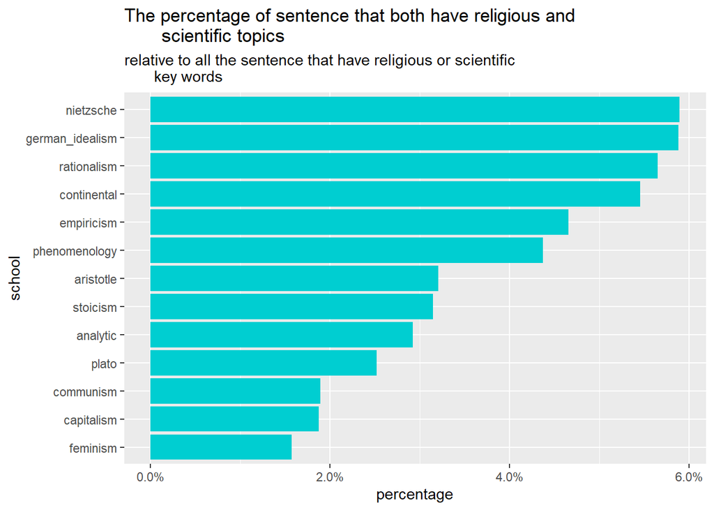

```r
sci_sentence%>%inner_join(rel_sentence,by = c("title", "author",
                                              "school", "sentence_str", "year",
                                              "sentence_length", "tokenized_txt",
                                              "lemmatized_str")
                          )%>%group_by(school)%>%summarise(sci_rel_count = n())%>%
  left_join(rbind(sci_sentence,rel_sentence)%>%unique%>%
              group_by(school)%>%summarise(sci_or_rel_count = n()),by = "school")%>%
  mutate(perc = sci_rel_count/sci_or_rel_count)%>%
  mutate(school = fct_reorder(school, perc))%>%
  ggplot(aes(x = school, y = perc)) + geom_col(fill = "darkturquoise") +
  coord_flip() +
  scale_y_continuous(labels = scales::percent) +
  scale_fill_discrete(name = "Type", labels = c("Religion", "Science")) +
  labs(title = "The percentage of sentence that both have religious and
       scientific topics",
       subtitle = "relative to all the sentence that have religious or scientific
       key words",
       y = "percentage")
```

In this graph, we calculated the percentage of sentences that both have scientific and religious words in one sentence to all sentences that are involved with religion and science. From the result graph, we can see that the highest percentage is about 6%. After we filter the sentences that are related to religion and science, we have about over 30,000 sentences. 6% of them is not that large, compared to the whole data set. Therefore, we cannot conclude that that science and religion are always brought up together.

## How does the sentiment toward science and religion for each school?

```r
rel_word_sep <- rel_sentence%>%
  mutate(sentence = map(sentence_str,
                              function(x)
                                str_replace_all(x, "\\,|\\!|\\?|\\'|\\-|\\(|\\)|\\.|\\/|\\:|
                                                ^|@|%|#|$|\\;",' ')))%>%
  mutate(word =
           map(sentence_str,function(x) strsplit(x,' ')))%>%
  select(-tokenized_txt,-lemmatized_str)%>%
  unnest(word)%>%unnest%>%filter(str_detect(word,'[a-zA-Z]'))
rel_sentence_word_count <- rel_word_sep%>%select(school,sentence_str,word)%>%
  group_by(school, sentence_str)%>%
  summarise(rel_sentence_word_n = n())
rel_sentence_word_n <- rel_sentence%>%
  inner_join(rel_sentence_word_count, by = c('school',"sentence_str"))%>%
  select(school, year, sentence_str,rel_sentence_word_n)

rel_sentiment <- get_nrc_sentiment(rel_sentence_word_n$sentence_str)
```

```r
rel_sentiment_perc <- rel_sentiment%>%select(positive,negative)%>%
  mutate(rel_determine = case_when(negative < positive ~ "positive",
                               negative > positive ~ "negative"))%>%
  cbind(rel_sentence)%>%select(school,rel_determine)%>%
  group_by(school,rel_determine)%>%
  na.omit()%>%
  summarise(count = n())%>%left_join(rel_sentence_school_count,by = "school")%>%
  select(school, rel_determine, count, rel_sentence_count)%>%
  mutate(rel_perc = count/rel_sentence_count)%>%
  select(school,rel_determine, rel_perc)
```

```r
sci_word_sep <- sci_sentence%>%
  mutate(sentence = map(sentence_str,
                              function(x)
                                str_replace_all(x, "\\,|\\!|\\?|\\'|\\-|\\(|\\)|\\.|\\/|\\:|
                                                ^|@|%|#|$|\\;",' ')))%>%
  mutate(word =
           map(sentence_str,function(x) strsplit(x,' ')))%>%
  select(-tokenized_txt,-lemmatized_str)%>%
  unnest(word)%>%unnest%>%filter(str_detect(word,'[a-zA-Z]'))
sci_sentence_word_count <- sci_word_sep%>%select(school,sentence_str,word)%>%
  group_by(school, sentence_str)%>%
  summarise(sci_sentence_word_n = n())
sci_sentence_word_n <- sci_sentence%>%
  inner_join(sci_sentence_word_count, by = c('school',"sentence_str"))%>%
  select(school, year, sentence_str,sci_sentence_word_n)

sci_sentiment <- get_nrc_sentiment(sci_sentence_word_n$sentence_str)
```

```r
sci_sentiment_perc <- sci_sentiment%>%select(positive,negative)%>%
  mutate(sci_determine = case_when(negative+1  < positive ~ "positive",
                               negative > positive+1  ~ "negative"))%>%
  cbind(sci_sentence)%>%select(school,sci_determine)%>%
  group_by(school,sci_determine)%>%
  na.omit()%>%
  summarise(count = n())%>%left_join(sci_sentence_school_count,by = "school")%>%
  select(school, sci_determine, count, sci_sentence_count)%>%
  mutate(sci_perc = count/sci_sentence_count)%>%
  select(school,sci_determine, sci_perc)
```

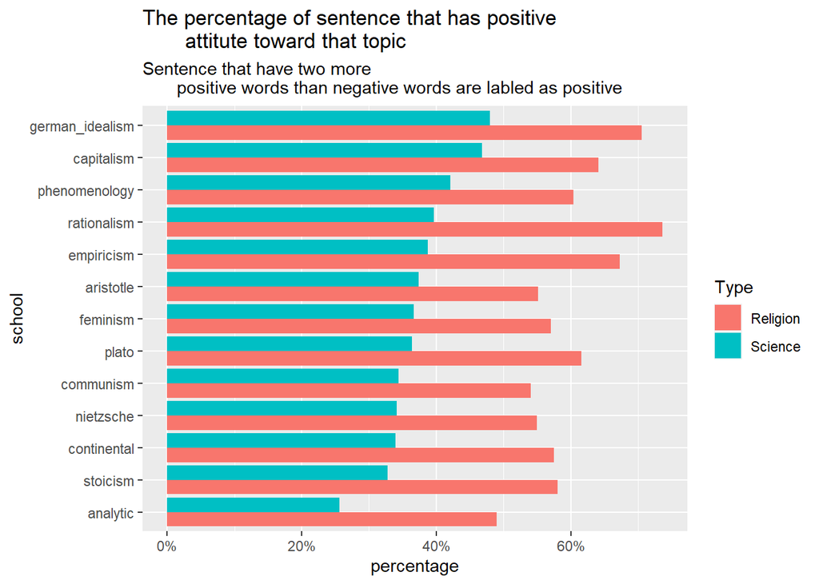

```r
pos_neg_school <- sci_sentiment_perc%>%left_join(rel_sentiment_perc, by = c('sci_determine' = 'rel_determine',"school"))%>%rename(type = sci_determine)

temp<-pos_neg_school%>%filter(type == "positive")
temp$school <- with(temp, reorder(school, sci_perc))

temp%>%mutate(school = fct_reorder(school, sci_perc))%>%
  pivot_longer(cols = c("sci_perc","rel_perc"))%>%
  ggplot(aes(x = school, y = value, fill = name)) +
  geom_col(position='dodge') + coord_flip()+
  scale_y_continuous(labels = scales::percent) +
  scale_fill_discrete(name = "Type", labels = c("Religion", "Science")) +
  labs(title = "The percentage of sentence that has positive
       attitute toward that topic",
       subtitle = "Sentence that have two more
       positive words than negative words are labled as positive",
       y = "percentage")
```